# Patterns of laser strikes on US aircraft: 2010 to 2018

Todd Curtis

November 21, 2019

### Summary

This study reviewed nine years of reports (2010-2018) compiled by the Federal Aviation Administration (FAA) concerning unauthorized laser illuminations of larger capacity transport aircraft (airliners, whether used for passenger or cargo service, that are designed to carry 60 or more passengers) in the US.

Among the findings was that the rate of reported laser events varies widely across the US (the 50 states, the District of Columbia, Puerto Rico, Guam, and other US territories), whether one looks at the rates in individual states or if one looks at the rates within selected US Census-designated Metropolitan Statistical Areas (MSAs).

In addition to examining the reporting rates, some of the insights from a review of the data included the following:

- *There were a total of 22,483 FAA laser incident reports from the years 2010-2018 that involved aircraft models of interest and that included information about the location of the encounter.
- Over that nine-year span, on any given day in the United States, there was a 98.2% chance that at least one large transport aircraft had a potentially dangerous encounter with a laser beam. In other words, in the 3,287-day period from 1 Janury 2010 to 31 December 2018, there were only 58 days without at least one reported laser incident involving a larger air carrier type aircraft.
- There were an average of 6.84 laser encounters per day, with as many as 33 strikes in a single day.
- Laser events were not uniformly distributed by time of day, with laser encounters more likely on Friday and Saturday, during the months of July through December, and from 0000-0600 hours UTC.
- The average rate of reported laser incidents in the United States was 18.14 per 100,000 air carrier flights. There were 23 states and 12 MSAs with a higher encounter rate.

### Background

In the US, the Federal Aviation Administration has long recognized that unauthorized laser illuminations of aircraft may have numerous hazardous effects on aircrew, including distraction, glare, afterimage, flash blindness, and, in extreme circumstances, persistent or permanent visual impairment ([FAA Advisory Circular 70-2A](http://www.faa.gov/documentLibrary/media/Advisory_Circular/AC_70-2A_.pdf)).

As part of their effort to deal with the hazards posed by lasers, the FAA has encouraged air crew members, air traffic controllers, and the general public to submit reports of aircraft being illuminated by lasers. The FAA has collected this kind of data since at least 2004, and in 2011 published a study ([Report DOT/FAA/AM-11/7](https://www.faa.gov/data_research/research/med_humanfacs/oamtechreports/2010s/media/201107.pdf)) that analyzed 2,492 laser events that occurred in the US from 2004-2008.

Since 2008, the FAA has received substantially more reports. [The FAA’s Laser News, Laws, & Civil Penalties page] (https://www.faa.gov/about/initiatives/lasers/laws/) provides a link to Excel files of data covering 2010-2018.

### Focus of this study

While the events in the FAA databases included reports from all sectors of aviation, including military operations, helicopters, and lighter-than-air aircraft, this study focused on events involving civilian operations involving large transport aircraft that were designed to carry 60 or more passengers. This in part due to the greater potential risk to both life and property when this kind of aircraft is struck by a laser.

### Aircraft models and air traffic used in this study

Because this study focused on larger airliner type aircraft, the FAA traffic data used to compute laser encounter rates helped define what models were included. The airport traffic data was taken from the ([FAA’s Operations Network (OPSNET)](https://aspm.faa.gov/opsnet/sys/Airport.asp)) site and covered the years 2010-2018.

The study focused on air carrier laser encounters, and only used air carrier traffic information. FAA defines air carrier aircraft as aircraft with a seating capacity of more than 60 seats or a maximum payload capacity of more than 18,000 pounds, carrying passengers or cargo for hire or compensation.

The events in this study, all of which were involved in civil aircraft flight operations, involved the following aircraft models:

- **Airbus:** A220, A300, A310, A318, A319, A320, A321, A330, A340, A350, A380
- **ATR:** ATR 72
- **Boeing:** 707, 727, 737, 747, 747, 757, 767, 777, 787
- **Boeing (McDonnell-Douglas):** 717, DC-8, DC-9, DC-10, MD-10, MD-11, MD-80, MD-90
- **Bombardier (Canadair):** C100, CRJ-700, CRJ-900
- **Bombardier (de Havilland):** Dash 8
- **Embraer:** ERJ 170, ERJ 175, ERJ 190

### Who is this report for?

This report may be useful for the following kinds of groups:

- Anyone who wants to educate flight crews, airport authorities, law enforcement and other relevant groups as to the extent of the problem (This could be done just cutting and pasting the graphics and basic stats in the report).
- Organizations that deal with policies related to the commercial use of lasers, for example pushing for specific limits on what can be sold to the public.
- Organizations currently involved in understanding or reducing aviation safety risks associated with inappropriate use of lasers.
- Organizations, especially law enforcement agencies that, that seek to understand when and where the risk of laser strikes are highest.

### Methods

After downloading the data and removing records that did not contain sufficient information on the location of the laser encounter, the data was processed in order to summarize the likelihood of a laser encounter by geographical area (specifially, states, territorries, and selected metropolitan areas), time of day, day of the week, and month of the year. Heat maps were used to help illustrate these relationships.

#### Laser encounter data preparation

The raw laser encounter data was included in an Excel file with each sheet containing information for one calendar year. The various sheets for 2010 to 2018 (the last available complete year at the time of this study) were combined to form one CSV file. There were several variables included for each record, including the following that were used in this study:

- Date
- Time (UTC)
- Aircraft ID
- Aircraft type
- Location (IATA or ICAO code)
- City
- State

The raw data file from the FAA contained numerous cases of incorrect data with respect to location (airport, city, and state), including misspellings and capitalization errors,as well as missing data. The events were manually reviewed to correct these errors when sufficient information was contained in the rest of the record.

Also, for consistency, locations were identified using the three-character IATA codes when they were available for an airport, navigation aid, or other location. Where IATA codes were not available, four-character ICAO codes were used.

Because part of this study focused on air carrier related laser events in selected metropolitan areas, part of the data preparation included adding three variables:

- **Event_ID:** A uniuqe identifier
- **Aircraft_Type:** Category variable for type of aircraft
- **Metro_area:** Identifier for a Metropolitan Statistical Areas (MSAs) as identified by the US Census publication Annual Estimates of the Resident Population: April 1, 2010 to July 1, 2018.

The MSAs used met one or more of the following criteria:

- The MSA was in the top 40 in population in 2018
- The MSA contained an airport that was a hub or major base of operations for one of the top 10 airlines by air carrier traffic

#### Laser encounter preliminary data cleaning

In addition to adding the above variables to each record, the raw data file from the FAA contained numerous cases of missing or incorrect data. The events were manually reviewed to correct these errors when sufficient information was contained in the rest of the record. The following types of changes were made:

- Incorrect, misspelled, or missing data for any variable was corrected or filled in when enough informaiton was available in the record.
- Removing duplicate records (also done a second time within the R program)
- Missing, incorrect, or incomplete data that could not be found or corrected were coded as “UNK”.
- Airports, navigational aids, and other locations identified using the three-character IATA codes or four-character ICAO codes whenever possible,
- In some cases, the airport location code was substituted for a navigational aid code when they were located at or near an airport. For example, sevearl reports for the city of Baltimore, MD used the ‘BAL’ IATA code, which is for the VORTAC at the field, and the arport code ‘BWI’ was substituted.
- Reported Laser colors were standardized by making all inputs with multiple identified colors of the form Color1/Color2, with the colors listed alphabetically, insuring that the first letter in a single word color identifier was capitalized, and correcting misspellings. Example: Blue and Green, became Multiple (Blue, Green), and Blue or green become Multiple (Blue or Green)

A variety of resources were used to identify key data for some records, including:

- [World Airport Codes](https://www.world-airport-codes.com/)
- [FlightAware](https://flightaware.com)
- [AirFleets](https://www.airfleets.net/home/)
- [Nations online](http://www.nationsonline.org/oneworld/IATA_Codes/airport_code_list.htm)
- [Locations identifier search tool](https://nfdc.faa.gov/xwiki/bin/view/NFDC/Location+Identifiers+Search+Tool)
- [AirNav.com](https://www.airnav.com/airports/)
- [US Census Bureau](https://www.census.gov/data/datasets/time-series/demo/popest/2010s-total-metro-and-micro-statistical-areas.html)

#### Preprocessed data and data dictionary

This preprocessed data is made available at http://www.airsafe.com/analyze/faa_laser_data_2010_2018.csv

The data dictionary that describes the variables in each record is available at http://www.airsafe.com/analyze/faa_laser_data_dictionary.pdf

### Data transformation

Additional data transformations and changes would occur after uploading:

- Initializing all data as type character prior to addiontal changes
- Removing leading and trailing spaces
- Changing all unknown data to type ‘NA’
- Removing duplicated records
- Using the date variable to create new variables for day of the month, day of the week, month, and year
- Using the time variable to create to new varibles for time in the HH:MM format, and a categorical variable with 25 values representing both the UTC hour and an uknown time value

Once the revisions were complete, a total of 18 duplicated records were removed.

Further processing changed the UTC times to an integer from one to 24 to coincide with the hour of occurrence. Additional variables were added for the day of the week and the month corresponding to the date.

Dates in the FAA data were in form 5-Jan-06, and were converted to the date format of yyyy-mm-dd. The converted dates were used to create two additional variables based on the date, the day of the week and, the month of the year, to ensure proper ordering, the two new variables were made into factors and ordered as they would be in a calendar.

There are initially 22483 total records, but only 22483 records have data in the most important variables: Date, Time, Aircraft_Type, Altitude, City, State.

### Quick summary of the data

Below are several summary graphics illustrating the distribution of laser encounters by:

- Frequency
- Year
- Month, and
- Day of the week

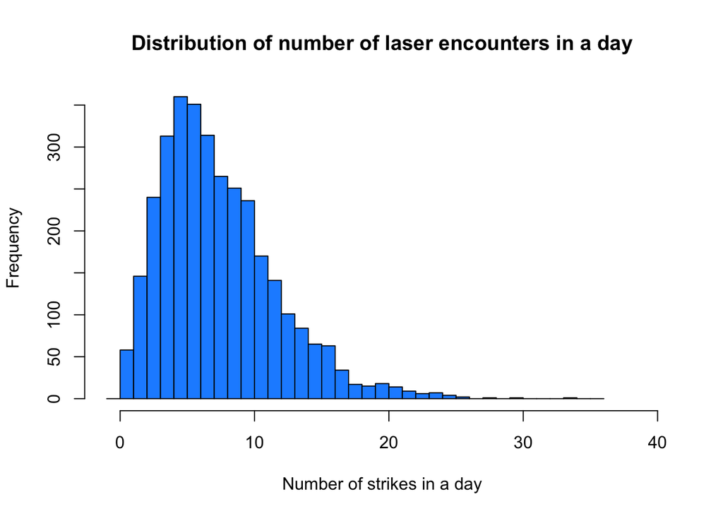

```
##    Min. 1st Qu.  Median    Mean 3rd Qu.    Max.
##    0.00    4.00    6.00    6.84    9.00   33.00
```

The following histograms illustrate the distribution of encounters by year, month, day of the week, and time of day (UTC) respectively.

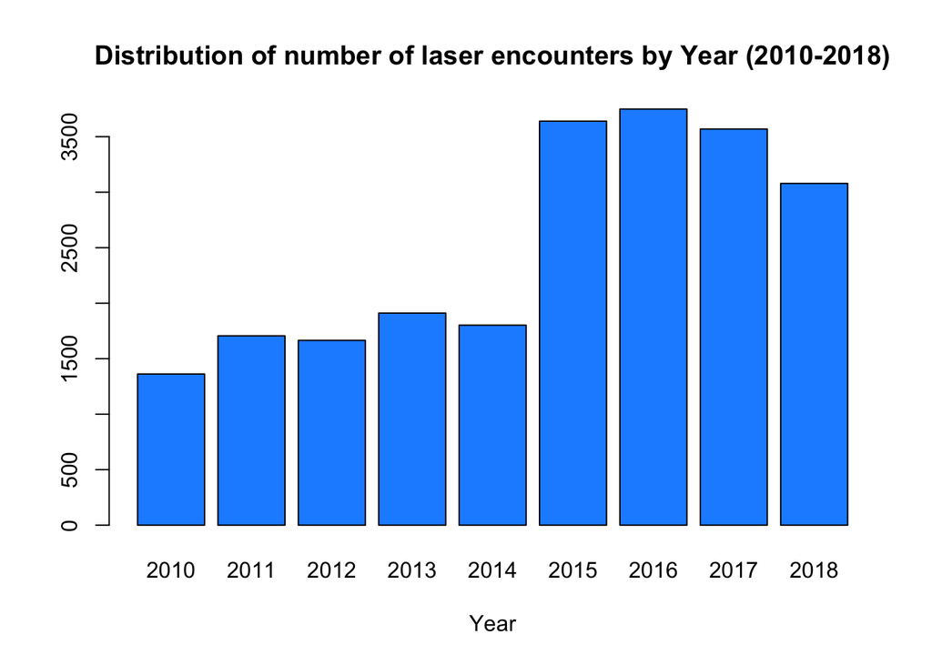

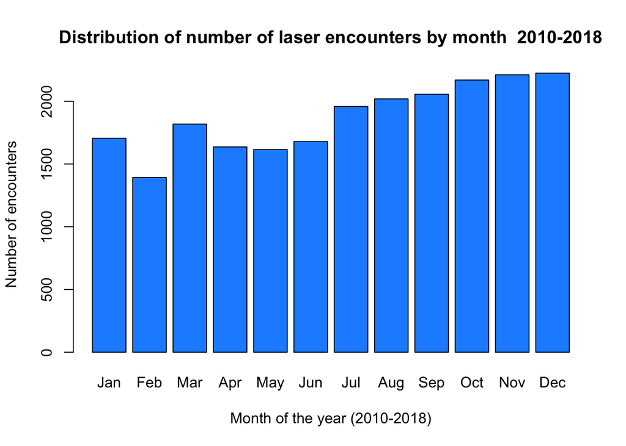

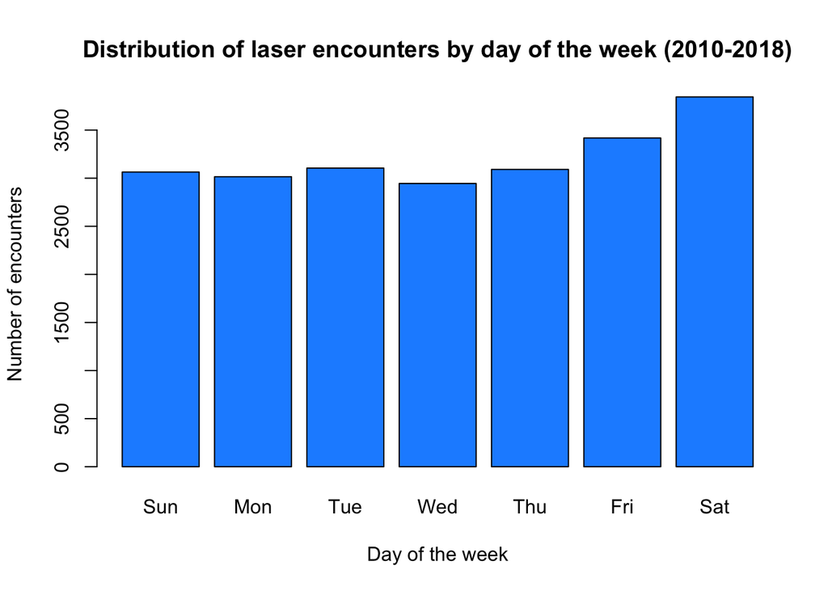

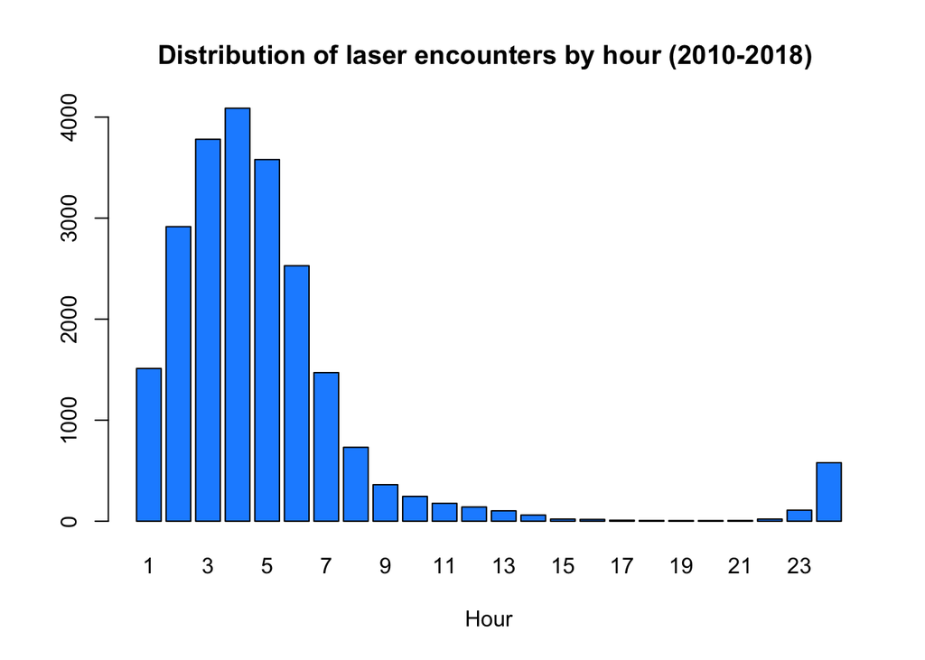

### Testing for uniform distribution of laser encounters

A chi-square test was used to test the null hypothesis that the laser strikes were uniformly distributed by the day of the week or the month of the year. The null hypothesis was rejected in both cases because the p-value was much less than 0.05:

- Day of the week p-value: 1.01e-37
- Month of the year p-value: 1.05e-85

The distribution by both day of the week and month of the year can be displayed by a table and tested as well for uniformity.

##### Table 1: Distribution of laser encounters by month and day of the week

The following table describes the distribution of laser encounters by day of the week and month of the year.

```
##
##       Sun Mon Tue Wed Thu Fri Sat
##   Jan 259 289 201 207 226 244 279
##   Feb 184 201 180 165 179 228 256
##   Mar 224 213 261 219 249 326 326
##   Apr 227 221 217 209 234 261 267
##   May 222 209 207 224 224 235 294
##   Jun 191 221 243 226 229 275 294
##   Jul 244 251 293 290 245 296 339
##   Aug 271 278 288 274 295 282 331
##   Sep 288 272 293 255 262 323 363
##   Oct 283 270 315 306 292 318 385
##   Nov 354 301 305 285 330 288 348
##   Dec 317 289 302 285 326 342 363
```

As was the case when conducting a chi-square test on the distribution of laser encounters by day of the week or month of the year, when considering the two together, the null hypothesis of a uniform distribution of strike encounters by a combination of day of the week and month of the year would also be rejected (p-value of 0.000163.

#### Using heat maps to illustrate relationships

It is also possible to visually depict this non-uniform distribution using heat maps. The heat map would reflect the data in the previous table, with 84 cells representing a combination of the month and day of the week. The colors correspond to a level of intensity with white being on the low end of the scale and dark blue on the upper end.

##### Heat map 1: Showing months with the most hits

There are three ways to display this heat map, all of which use the data in Table 1. In the first option, the darkest cell corresponds to the month of the year and day of the week with the most laser encounters.

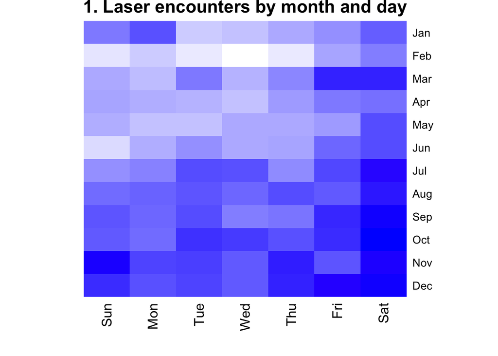

##### Heat map 2: Showing days of the week with the most hits

By scaling the heat map by the row values (month of the year), the darker cells in each row correspond to the days of the week with the most laser encounters. This means that a column that is consistently darker would correspond to the days of the week that is more likely to have laser encounters.

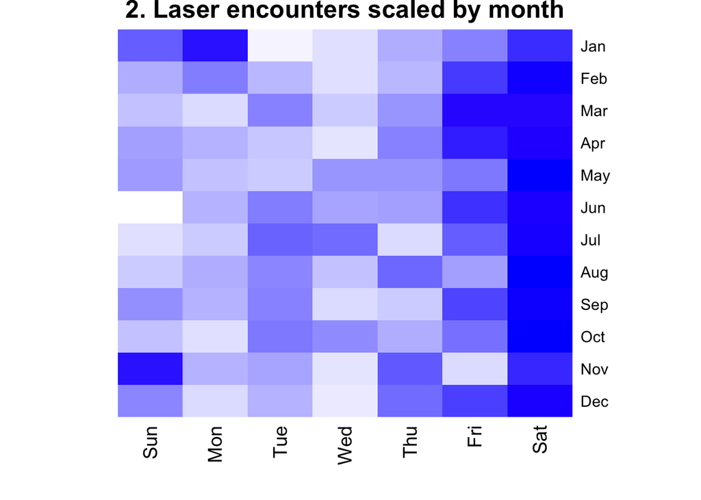

This second heat map show that for most months of the year, Friday and Saturday have a consistently higher number of laser encounter reports than other days of the week.

##### Heat map 3: Showing months of the year with the most hits

By scaling the heat map by the column values (day of the week), the darker cells in each column correspond to the months with the most laser encounters.

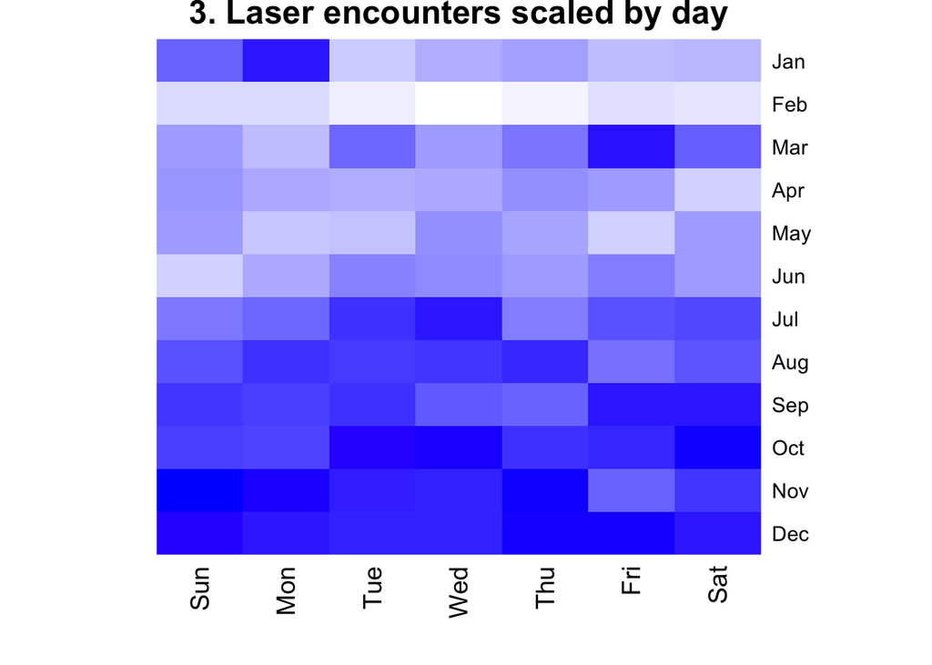

#### What the first three heat maps suggest

Using the same table of data summarizing the distribution of strikes by a combination of month of the year and day of the week, the three heat maps highlighted the following:

- Heat map #1: The combination of month and day with relatively high numbers of laser encounters.
- Heat map #2: The days of the week with consistently higher levels of stirke reports throughout the year.
- Heat map #3: The months of the year with consistently higher levels of strike reports.

Together, the Table 1 and the three heat maps suggest a clear overall pattern of laser encounter reporting that is consistent with higher levels of laser encounters occurring from July through December, and also on Friday and Saturday.

These general trends were evident, but not as strongly, in the unscaled heat map. This suggest that the scaled heat maps are preferable for exposing laser encounter trends associated with particular days of the week or months of the year.

#### When laser encounters happen during the day

While laser encounters could potentially occur at any time of day, they would be most notable well after sunset or well before sunrise. That is reflected by the fact that for the US as a whole, about 81.9% of the reports were for encounters that occurred between 0000 and 0600 hours UTC, which would correspond to between 5 p.m. and 11 p.m in the Pacific Time Zone and 8 p.m. and 2 a.m. in the Eastern Time Zone during Daylight Savings Time, and an hour earlier during Standard Time.

##### Table 2: Laser encounters by hour and month

```
##
##      Jan Feb Mar Apr May Jun Jul Aug Sep Oct Nov Dec
##   1  152 117 117  90  44  17  23  73 177 239 230 233
##   2  200 181 216 215 171 150 166 270 337 330 344 336
##   3  290 272 325 272 277 276 330 323 359 429 316 312
##   4  268 220 356 315 330 381 407 408 395 373 320 315
##   5  229 177 285 326 328 320 401 369 307 277 305 256
##   6  198 168 203 194 236 233 262 238 196 159 213 229
##   7  133 105 136  90  93 149 187 129 107  72 134 136
##   8   54  48  63  51  47  67  82  76  52  42  78  72
##   9   18  20  30  26  38  36  32  45  18  29  34  36
##   10  14  11  16  11  22  16  29  31  28  25  22  21
##   11  18  10  20  10   8   5  13  21  13  21  16  22
##   12  13  10   7   7   5   4   3  15   9  16  17  35
##   13   6   7  10   8   4   5   4   6  15   6  10  22
##   14   7   4   5   1   1   5   0   3   5  13   7  10
##   15   7   0   1   1   1   0   0   0   0   0   2   9
##   16   3   1   0   2   1   1   2   0   2   1   3   2
##   17   2   0   1   0   1   2   0   0   0   1   1   2
##   18   2   0   0   0   0   1   0   0   0   0   1   3
##   19   0   1   0   0   0   2   0   0   0   0   2   1
##   20   0   2   0   0   0   1   1   1   0   1   0   0
##   21   0   0   1   1   0   0   1   0   1   0   0   3
##   22   0   2   3   1   2   1   4   1   0   0   1   6
##   23  10   1   1   5   2   2   1   3   2  12  28  42
##   24  81  36  22  10   4   5  10   7  33 123 127 121
```

The heat map below, which is scaled by the month of the year (the x-axis) shows a seasonal shift in reporting, with with the concentration of reports shifting to later in the day from May to August.

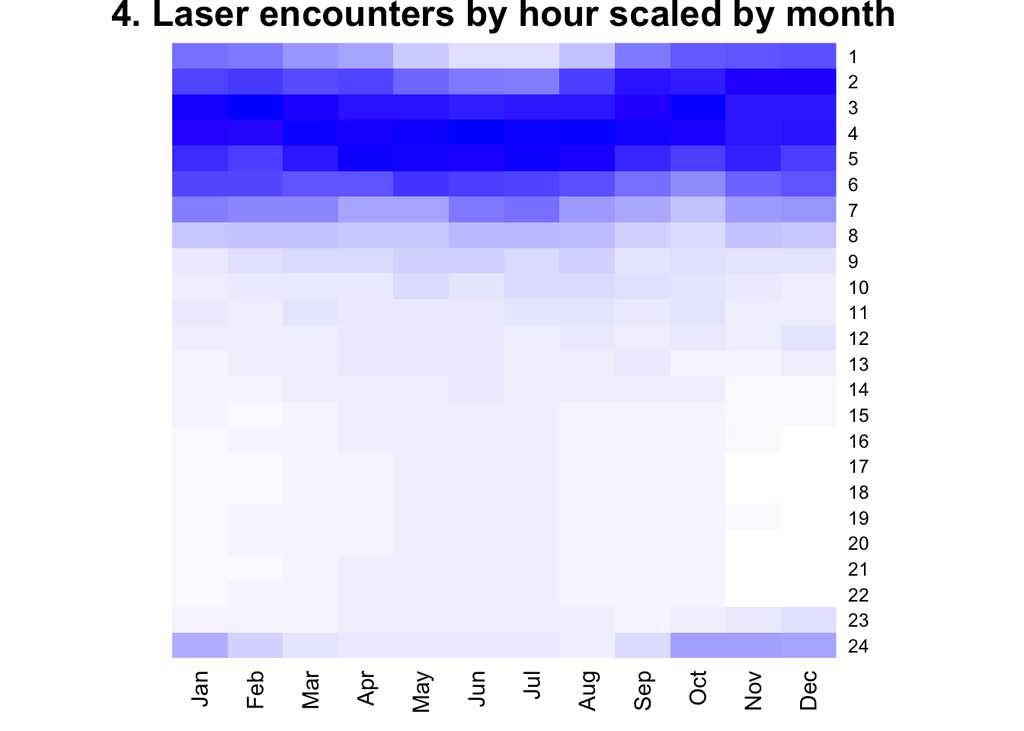

### Illustrating risk: States vs. MSAs

Risk can be defined as the product of a hazard (such as damage costs) and the probability that this hazard occurs. In other words, (probability)x(hazard) = risk. In this study, the hazard is a laser encounter and the probability is the number of events per 100,000 flights.

This study examined two ways of comparing relative risk : comparing the rate of lasers encounters among the states of the US, and comparing the rate among the 44selected MSAs, including those representing the top 40 in population in 2018.

The selcted MSAs were used in part because air traffic isn’t concentrated in states as a whole, but rather in the portions of the state where the air traffic is concentrated. MSAs were also attractive because several of the major nodes of air carrier traffic, such as New York: Washington, DC, Chicago, and St. Louis, are in MSAs that cover more than one state.

### State laser encounter comparisons

The following table has information from all the states and territories orderd by:

- State or territory name
- Number of air carrier operations,
- Number of laser encounters, and
- Rate of laser encounters

#### Table 3: States and territories data ordered by name

```
##                     State Operations (M) Events Rate per 100K
##                   Alabama           0.42    148         35.50
##                    Alaska           1.19     30          2.52
##                   Arizona           3.69   1112         30.12
##                  Arkansas           0.30     68         22.42
##                California          14.68   4984         33.96
##                  Colorado           4.29    489         11.40
##               Connecticut           0.50    119         23.67
##                  Delaware           0.00     27        992.65
##      District of Columbia           1.90    109          5.75
##                   Florida          11.17   1615         14.46
##                   Georgia           7.01    466          6.65
##                      Guam           0.20     14          6.98
##                    Hawaii           2.44    404         16.57
##                     Idaho           0.40     89         22.15
##                  Illinois           6.97    746         10.71
##                   Indiana           1.07    477         44.73
##                      Iowa           0.29     88         29.83
##                    Kansas           0.15     55         37.65
##                  Kentucky           1.75    747         42.77
##                 Louisiana           1.02    154         15.02
##                     Maine           0.21     25         11.95
##                  Maryland           1.90    241         12.68
##             Massachusetts           2.49    234          9.40
##                  Michigan           2.66    313         11.79
##                 Minnesota           2.70    287         10.62
##               Mississippi           0.13     48         37.71
##                  Missouri           2.17    289         13.32
##                   Montana           0.32     39         12.04
##                  Nebraska           0.42     53         12.70
##                    Nevada           3.52    676         19.22
##             New Hampshire           0.21     34         16.08
##                New Jersey           2.80    477         17.03
##                New Mexico           0.52    159         30.40
##                  New York           7.38    796         10.79
##            North Carolina           4.57    397          8.68
##              North Dakota           0.13     16         12.70
##  Northern Mariana Islands           0.05      0          0.00
##                      Ohio           1.49    308         20.60
##                  Oklahoma           0.67    157         23.38
##                    Oregon           1.67    683         40.84
##              Pennsylvania           3.16    608         19.27
##               Puerto Rico           0.70    451         64.46
##              Rhode Island           0.31     65         20.86
##            South Carolina           0.64    171         26.66
##              South Dakota           0.11     17         15.97
##                 Tennessee           2.74    441         16.12
##                     Texas          12.01   2021         16.82
##                      Utah           1.72    442         25.75
##                   Vermont           0.11     14         12.42
##            Virgin Islands           0.10      1          0.96
##                  Virginia           2.20    240         10.93
##                Washington           3.81    692         18.18
##             West Virginia           0.05     47         99.08
##                 Wisconsin           0.80     93         11.60
##                   Wyoming           0.08      7          9.23
```

#### Table 4: States and territories data ordered by air carrier operations

```
##                     State Operations (M) Events Rate per 100K
##                California          14.68   4984         33.96
##                     Texas          12.01   2021         16.82
##                   Florida          11.17   1615         14.46
##                  New York           7.38    796         10.79
##                   Georgia           7.01    466          6.65
##                  Illinois           6.97    746         10.71
##            North Carolina           4.57    397          8.68
##                  Colorado           4.29    489         11.40
##                Washington           3.81    692         18.18
##                   Arizona           3.69   1112         30.12
##                    Nevada           3.52    676         19.22
##              Pennsylvania           3.16    608         19.27
##                New Jersey           2.80    477         17.03
##                 Tennessee           2.74    441         16.12
##                 Minnesota           2.70    287         10.62
##                  Michigan           2.66    313         11.79
##             Massachusetts           2.49    234          9.40
##                    Hawaii           2.44    404         16.57
##                  Virginia           2.20    240         10.93
##                  Missouri           2.17    289         13.32
##      District of Columbia           1.90    109          5.75
##                  Maryland           1.90    241         12.68
##                  Kentucky           1.75    747         42.77
##                      Utah           1.72    442         25.75
##                    Oregon           1.67    683         40.84
##                      Ohio           1.49    308         20.60
##                    Alaska           1.19     30          2.52
##                   Indiana           1.07    477         44.73
##                 Louisiana           1.02    154         15.02
##                 Wisconsin           0.80     93         11.60
##               Puerto Rico           0.70    451         64.46
##                  Oklahoma           0.67    157         23.38
##            South Carolina           0.64    171         26.66
##                New Mexico           0.52    159         30.40
##               Connecticut           0.50    119         23.67
##                   Alabama           0.42    148         35.50
##                  Nebraska           0.42     53         12.70
##                     Idaho           0.40     89         22.15
##                   Montana           0.32     39         12.04
##              Rhode Island           0.31     65         20.86
##                  Arkansas           0.30     68         22.42
##                      Iowa           0.29     88         29.83
##                     Maine           0.21     25         11.95
##             New Hampshire           0.21     34         16.08
##                      Guam           0.20     14          6.98
##                    Kansas           0.15     55         37.65
##               Mississippi           0.13     48         37.71
##              North Dakota           0.13     16         12.70
##              South Dakota           0.11     17         15.97
##                   Vermont           0.11     14         12.42
##            Virgin Islands           0.10      1          0.96
##                   Wyoming           0.08      7          9.23
##  Northern Mariana Islands           0.05      0          0.00
##             West Virginia           0.05     47         99.08
##                  Delaware           0.00     27        992.65
```

#### Table 4: States and territories data ordered by laser encounters

```
##                     State Operations (M) Events Rate per 100K
##                California          14.68   4984         33.96
##                     Texas          12.01   2021         16.82
##                   Florida          11.17   1615         14.46
##                   Arizona           3.69   1112         30.12
##                  New York           7.38    796         10.79
##                  Kentucky           1.75    747         42.77
##                  Illinois           6.97    746         10.71
##                Washington           3.81    692         18.18
##                    Oregon           1.67    683         40.84
##                    Nevada           3.52    676         19.22
##              Pennsylvania           3.16    608         19.27
##                  Colorado           4.29    489         11.40
##                New Jersey           2.80    477         17.03
##                   Indiana           1.07    477         44.73
##                   Georgia           7.01    466          6.65
##               Puerto Rico           0.70    451         64.46
##                      Utah           1.72    442         25.75
##                 Tennessee           2.74    441         16.12
##                    Hawaii           2.44    404         16.57
##            North Carolina           4.57    397          8.68
##                  Michigan           2.66    313         11.79
##                      Ohio           1.49    308         20.60
##                  Missouri           2.17    289         13.32
##                 Minnesota           2.70    287         10.62
##                  Maryland           1.90    241         12.68
##                  Virginia           2.20    240         10.93
##             Massachusetts           2.49    234          9.40
##            South Carolina           0.64    171         26.66
##                New Mexico           0.52    159         30.40
##                  Oklahoma           0.67    157         23.38
##                 Louisiana           1.02    154         15.02
##                   Alabama           0.42    148         35.50
##               Connecticut           0.50    119         23.67
##      District of Columbia           1.90    109          5.75
##                 Wisconsin           0.80     93         11.60
##                     Idaho           0.40     89         22.15
##                      Iowa           0.29     88         29.83
##                  Arkansas           0.30     68         22.42
##              Rhode Island           0.31     65         20.86
##                    Kansas           0.15     55         37.65
##                  Nebraska           0.42     53         12.70
##               Mississippi           0.13     48         37.71
##             West Virginia           0.05     47         99.08
##                   Montana           0.32     39         12.04
##             New Hampshire           0.21     34         16.08
##                    Alaska           1.19     30          2.52
##                  Delaware           0.00     27        992.65
##                     Maine           0.21     25         11.95
##              South Dakota           0.11     17         15.97
##              North Dakota           0.13     16         12.70
##                      Guam           0.20     14          6.98
##                   Vermont           0.11     14         12.42
##                   Wyoming           0.08      7          9.23
##            Virgin Islands           0.10      1          0.96
##  Northern Mariana Islands           0.05      0          0.00
```

#### Table 5: States and territories data ordered by laser encounter rate

```
##                     State Operations (M) Events Rate per 100K
##                  Delaware           0.00     27        992.65
##             West Virginia           0.05     47         99.08
##               Puerto Rico           0.70    451         64.46
##                   Indiana           1.07    477         44.73
##                  Kentucky           1.75    747         42.77
##                    Oregon           1.67    683         40.84
##               Mississippi           0.13     48         37.71
##                    Kansas           0.15     55         37.65
##                   Alabama           0.42    148         35.50
##                California          14.68   4984         33.96
##                New Mexico           0.52    159         30.40
##                   Arizona           3.69   1112         30.12
##                      Iowa           0.29     88         29.83
##            South Carolina           0.64    171         26.66
##                      Utah           1.72    442         25.75
##               Connecticut           0.50    119         23.67
##                  Oklahoma           0.67    157         23.38
##                  Arkansas           0.30     68         22.42
##                     Idaho           0.40     89         22.15
##              Rhode Island           0.31     65         20.86
##                      Ohio           1.49    308         20.60
##              Pennsylvania           3.16    608         19.27
##                    Nevada           3.52    676         19.22
##                Washington           3.81    692         18.18
##                New Jersey           2.80    477         17.03
##                     Texas          12.01   2021         16.82
##                    Hawaii           2.44    404         16.57
##                 Tennessee           2.74    441         16.12
##             New Hampshire           0.21     34         16.08
##              South Dakota           0.11     17         15.97
##                 Louisiana           1.02    154         15.02
##                   Florida          11.17   1615         14.46
##                  Missouri           2.17    289         13.32
##                  Nebraska           0.42     53         12.70
##              North Dakota           0.13     16         12.70
##                  Maryland           1.90    241         12.68
##                   Vermont           0.11     14         12.42
##                   Montana           0.32     39         12.04
##                     Maine           0.21     25         11.95
##                  Michigan           2.66    313         11.79
##                 Wisconsin           0.80     93         11.60
##                  Colorado           4.29    489         11.40
##                  Virginia           2.20    240         10.93
##                  New York           7.38    796         10.79
##                  Illinois           6.97    746         10.71
##                 Minnesota           2.70    287         10.62
##             Massachusetts           2.49    234          9.40
##                   Wyoming           0.08      7          9.23
##            North Carolina           4.57    397          8.68
##                      Guam           0.20     14          6.98
##                   Georgia           7.01    466          6.65
##      District of Columbia           1.90    109          5.75
##                    Alaska           1.19     30          2.52
##            Virgin Islands           0.10      1          0.96
##  Northern Mariana Islands           0.05      0          0.00
```

### The Delaware outlier

In Table 5, the state of Delaware stands out because of its very high rate of laser encounters. This is due to its relativley low number of air carrier operations. In the nine years of the study, Delaware had only 2,720 air carrier flight operations, or 0.83, flights per day, compared to the next highest state or territory, West Virginia, which had 47,438 air carrier flight operations, or 14.43 flights per day.

The number of reported laser encounters in Delaware, was likely not due to air carrier operations within the state, but rather to Delaware’s locaiton within an area of high air carrier activity in the northeast US.

### Laser encounters by state

The FAA collected laser encounter data for a total of 54 states and territories. The most encounters were in California with 4,984. The encounters were concentrated in a few states, with only 14 states and territories having on average more than one reported laser encounter per week.

#### Laser heat maps

The following three maps illustrate the extent of the hazard in the continental US, as well as a key weakness of comparing rates of laser encounters by state.

The first heat map depicts the disribution of air carrier traffic by state.

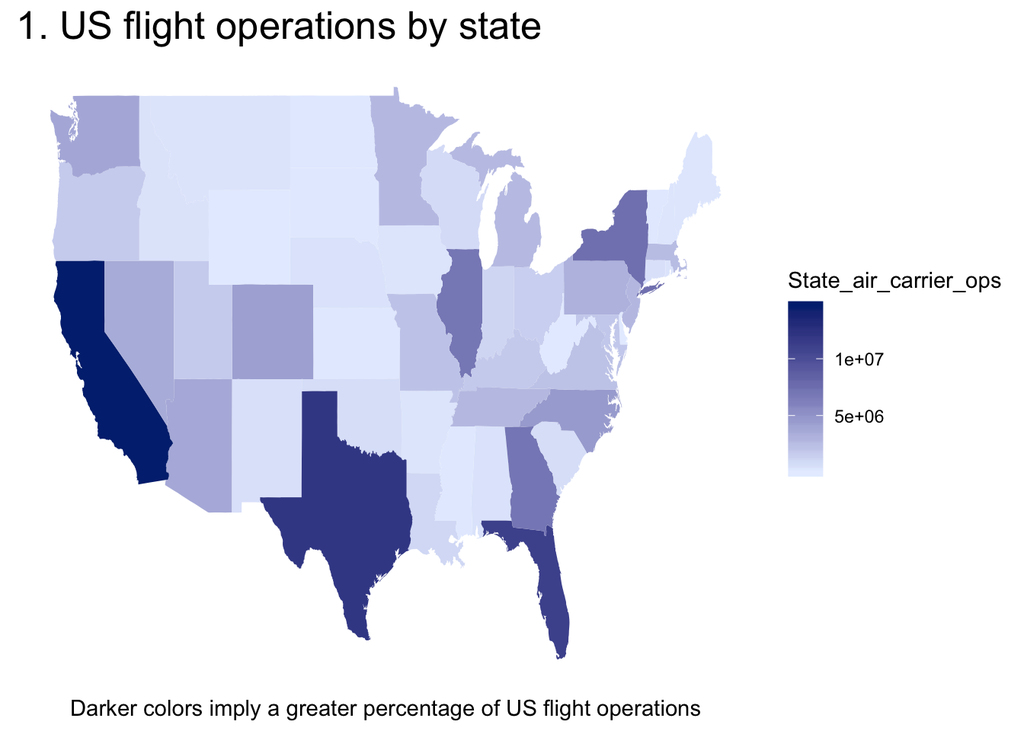

The second heat map depicts the distribution of the the number of laser encounters by state.

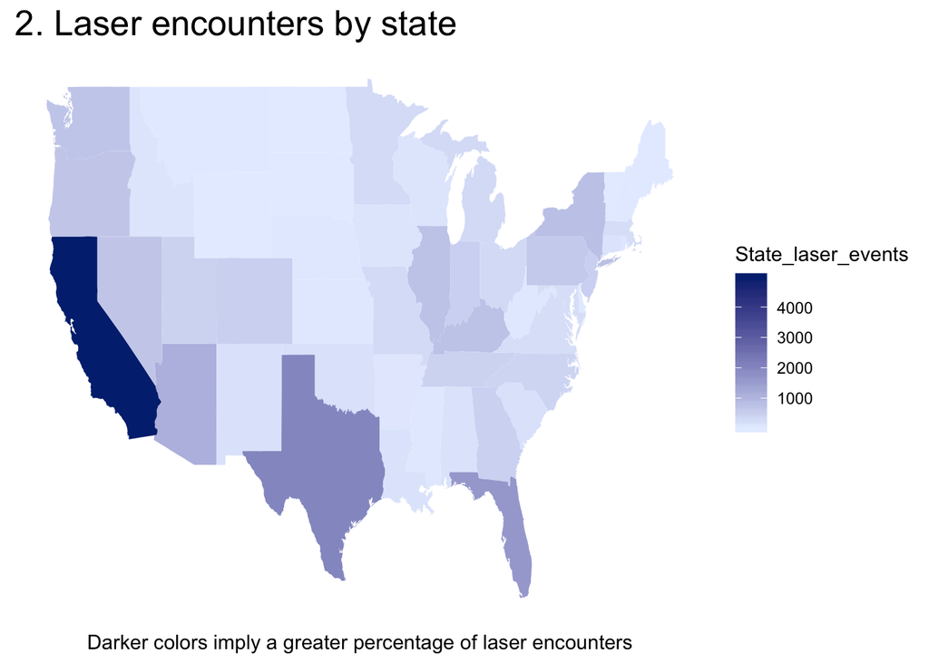

The last heat map shows the relative rate of laser encounters per 100K air carrier flights.

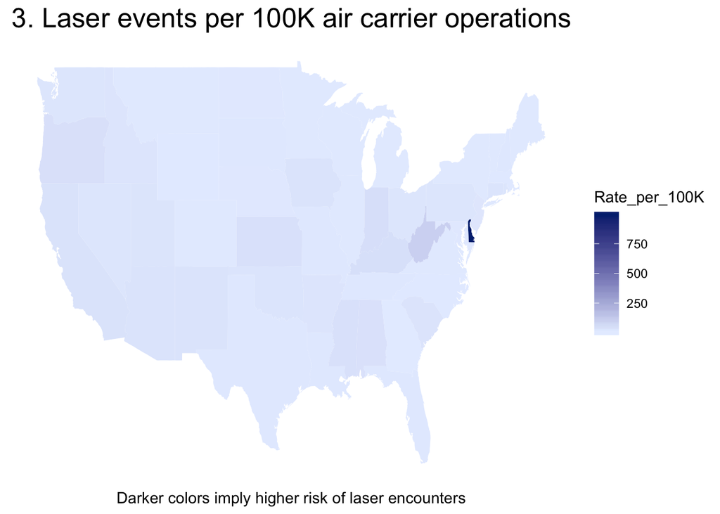

#### Key issues when comparing state laser encounter rates

There are three key issues with using traffic and laser encounter data on the state level:

- Relatively small numbers of air carrier operations in smaller states,
- Larger states which may have several distinct areas of both high air carrier traffic and reported laser encounters, and
- Heavily populated regions that may have regional air traffic and laser reports spread over two or more states.

The first type of issue is illutrated by the three heat maps depicted the continental US. In the first two heat maps, it is clear from the layout which states have a disproportionate share of air carrier traffic or reported laser encounters.

The third graphic illustrates all three of the key issues:

-This last graphic also does not show where the very active areas within a state may be, especially if an active area has flight operations and laser events spread over sevearal states.

### Laser risks in selected metropolitan areas

An alternative to comparing rates by state is to do so with a different geographical grouping, specifically the Metropolitan Statistical Areas (MSAs) defined by the US Census Bureau. As mentioned before, all the MSAs were either among the top 40 in poplulation in 2018, or the MSA had a major hub airport for one or more airlines that was among the to ten in laser encounters. Those airlines are listed below:

#### Table 6: Top 10 airlines by laser encounters

```
##  Airline Events Weekly rate
##      SWA   4246        9.05
##      AAL   2278        4.85
##      DAL   2260        4.81
##      UAL   2087        4.45
##      SKW   1132        2.41
##      ASA   1042        2.22
##      JBU    984        2.10
##      UPS    969        2.06
##      FDX    929        1.98
##      RPA    657        1.40
```

Based on the locations of the hubs or major operating locations of these 10 airlines, the following MSAs were added from outside the top 40:

- Anchorage, AK
- Louisville, KY
- Memphis, TN
- Salt Lake City, UT

A total of 44 metropolitan areas were reviewed to determine the laser event risk of a general geographic area. Each metropolitan area included any airport or other location with at least one air carrier event, or one air carrier operation.

The following 44 metropolitan statistical areas (MSAs) were analyzed to determine the number and rate of laser events in those areas: Anchorage, Atlanta, Austin, Baltimore, Boston, Charlotte, Chicago, Cincinnati, Cleveland, Columbus, Dallas, Denver, Detroit, Houston, Indianapolis, Kansas City, Las Vegas, Los Angeles, Louisville, Memphis, Miami, Milwaukee, Minneapolis, Nashville, New York, Orlando, Philadelphia, Phoenix, Pittsburgh, Portland, Providence, Riverside, Sacramento, Saint Louis, Salt Lake City, San Antonio, San Diego, San Francisco, San Jose, San Juan, Seattle, Tampa, Virginia Beach, Washington_DC

The number of laser encounters among these MSAs represented 74.5% of all laser encounters involving air carrier aircraft

#### Table 7: Metropolitan areas ordered by rate of encounters

```
##      Metro_area Events Rate_per_100K
##       Riverside    532         81.02
##        San Jose    530         60.63
##        Portland    592         40.10
##       San Diego    571         38.37
##      Louisville    323         34.19
##    Indianapolis    308         31.22
##     San Antonio    228         27.36
##         Phoenix    921         27.34
##     Los Angeles   1694         26.52
##   San Francisco    809         19.47
##      Sacramento    158         18.76
##       Nashville    178         18.15
##          All_US  22483         18.14
##         Houston    674         17.89
##      Cincinnati    129         17.56
##    Philadelphia    364         16.52
##         Seattle    525         16.21
##      Pittsburgh    116         15.09
##          Austin    194         14.81
##  Salt Lake City    361         13.98
##        San Juan    418         13.94
##           Miami    755         13.79
##           Tampa    196         13.69
##         Orlando    370         13.58
##        Columbus     78         13.29
##     Kansas City    127         13.26
##       Cleveland     75         12.49
##         Memphis    178         11.15
##       Baltimore    209         11.04
##        New York    982         10.91
##         Chicago    745         10.81
##          Denver    426         10.64
##  Virginia Beach     29         10.62
##     Saint Louis    117         10.20
##         Detroit    233         10.14
##     Minneapolis    265          9.91
##          Dallas    531          9.58
##          Boston    207          8.41
##   Washington_DC    273          7.92
##       Milwaukee     44          7.55
##       Las Vegas    580          7.18
##       Charlotte    244          7.16
##         Atlanta    368          5.40
##      Providence     67          2.42
##       Anchorage     19          1.99
```

The following states and territories were included in one or more MSAs: Alaska, Arizona, California, Colorado, Connecticut, Delaware, District of Columbia, Florida, Georgia, Illinois, Indiana, Kansas, Kentucky, Maryland, Massachusetts, Michigan, Minnesota, Missouri, Nevada, New Hampshire, New Jersey, New York, North Carolina, Ohio, Oregon, Pennsylvania, Puerto Rico, Rhode Island, Tennessee, Texas, Utah, Virginia, Washington, West Virginia, Wisconsin

The airports in the included MSAs included 85.1% of all air carrier traffic and 74.5% of all laser encounter events.

The areas outside of any MSA included 14.9% of all air carrier traffic and 25.5% of all air carrier laser encounters.

The MSAs did not include territory from any of the following states and territorries: Alabama, Arkansas, Guam, Hawaii, Idaho, Iowa, Louisiana, Maine, Mississippi, Montana, Nebraska, New Mexico, North Dakota, Northern Mariana Islands, Oklahoma, South Carolina, South Dakota, Vermont, Virgin Islands, Wyoming.

### Discussion

The laser encounter data collected by the FAA represents an important resource for understanding the kinds of current and future risks that aircraft face from lasers. This study was focused on the distribution of laser encounters and how visual summaries such as heat maps can be used in conjunction with statistical measurements to communicate the scale and scope of the problem.

The raw data provided by the FAA required further processing before it could used in this study, and that data cleaning processed revealed a number of issues with the data collection process, including inconsistencies in how airport identifiers are used.

Variations in encounter rates among the states were evaluated, as were variations among the largest metropolitan areas. It was not possible to observe regional differences within a state, particularly large states like California and Texas, and the Census-defined MSAs often cross state boundaries.

Combining both the selected MSAs and the states that did not have any territory in a selected MSA, and doing so in a way that did not have any overlapping areas, allowed for both an identification of higher risk areas in the selected MSAs in the context of the risks in the states and territories that were not partially or fully within a selected MSA.

### Resources

Laser Illumination of Flight Crew Personnel by Month, Day of Week, and Time of Day for a 5-Year Study Period: 2004-2008 DOT/FAA/AM-11/7 https://www.faa.gov/data_research/research/med_humanfacs/oamtechreports/2010s/media/201107.pdf

FAA’s Air Traffic Activity System (ATADS) https://aspm.faa.gov/opsnet/sys/Airport.asp

Laser Incidents (FAA) https://www.faa.gov/about/initiatives/lasers/laws/

Reported Laser Incidents for 2010-2014 (FAA) https://www.faa.gov/about/initiatives/lasers/laws/media/laser_incidents_2010-2014.xls

Processed Laser Incident data used in this study http://www.airsafe.com/analyze/faa_laser_data_2010_2018.csv

US Census Bureau Annual Estimates of the Resident Population: April 1, 2010 to July 1, 2018 https://www.census.gov/data/datasets/time-series/demo/popest/2010s-total-metro-and-micro-statistical-areas.html

Air Traffic Activity System (FAA) https://aspm.faa.gov/opsnet/sys/Airport.asp

Patterns of laser strikes on US aircraft: 2010 to 2018 (this report)

- HTML - http://www.airsafe.com/analyze/laser_strikes_2010_2018.html
- Rmd - http://www.airsafe.com/analyze/laser_strikes_2010_2018.Rmd
- R (background analysis) - http://www.airsafe.com/analyze/laser_strikes_2010_2018.R
- RPubs - http://rpubs.com/airsafe/lasers_2010_2018